# Bellabeat Analysis

Sewuese

2024-11-09

## Introduction

Bellabeat founded by Urška Sršen and Sando Mur, is a high-tech company that manufactures health-focused smart products. Sršen used her background as an artist to develop beautifully designed technology that informs and inspires women around the world. Collecting data on activity, sleep, stress, and reproductive health has allowed Bellabeat to empower women with knowledge about their own health and habits. Since it was founded in 2013, Bellabeat has grown rapidly and quickly positioned itself as a tech-driven wellness company for women.

## Major Objective

To identify potential opportunities for growth and provide recommendations for the Bellabeat marketing strategy improvement based on trends in smart device usage.

## Ask

1. What are some trends in smart device usage?
2. How could these trends apply to Bellabeat customers?
3. How could these trends help influence Bellabeat marketing strategy?

## Prepare

I will be using the following tables:

[output not shown]

## Dataset Concerns

The small sample size of around thirty users, along with the lack of demographic information, introduces concerns about sampling bias, as it’s uncertain whether this sample accurately reflects the broader population. Moreover, the dataset is outdated, and data collection spanned only two months, which further limits the representativeness and validity of the findings.

## Process

For this project, I will be using RStudio for my analysis because it is user-friendly, easy to read, accessible, and allows us to create visualizations all within a single program.

## setting up my environment

Notes: setting up my R environment by loading the packages

```r
library(tools)
library(tidyverse)
```

## Importing Table

Notes: importing and renaming my dataset

```r
dailyActivity_merge <- read.csv ("~/Fitabase Data 4.12.16-5.12.16/dailyActivity_merged.csv")

weightLogInfo_merged <- read.csv("~/Fitabase Data 4.12.16-5.12.16/weightLogInfo_merged.csv")
```

## Previewing Tables

Notes: previewing my tables to get an idea of the data I will be working with

```r
head(dailyActivity_merge)
```

```
##           Id ActivityDate TotalSteps TotalDistance TrackerDistance
## 1 1503960366    4/12/2016      13162          8.50            8.50
## 2 1503960366    4/13/2016      10735          6.97            6.97
## 3 1503960366    4/14/2016      10460          6.74            6.74
## 4 1503960366    4/15/2016       9762          6.28            6.28
## 5 1503960366    4/16/2016      12669          8.16            8.16
## 6 1503960366    4/17/2016       9705          6.48            6.48
##   LoggedActivitiesDistance VeryActiveDistance ModeratelyActiveDistance
## 1                        0               1.88                     0.55
## 2                        0               1.57                     0.69
## 3                        0               2.44                     0.40
## 4                        0               2.14                     1.26
## 5                        0               2.71                     0.41
## 6                        0               3.19                     0.78
##   LightActiveDistance SedentaryActiveDistance VeryActiveMinutes
## 1                6.06                       0                25
## 2                4.71                       0                21
## 3                3.91                       0                30
## 4                2.83                       0                29
## 5                5.04                       0                36
## 6                2.51                       0                38
##   FairlyActiveMinutes LightlyActiveMinutes SedentaryMinutes Calories
## 1                  13                  328              728     1985
## 2                  19                  217              776     1797
## 3                  11                  181             1218     1776
## 4                  34                  209              726     1745
## 5                  10                  221              773     1863
## 6                  20                  164              539     1728
```

```r
head(weightLogInfo_merged)
```

```
##           Id                  Date WeightKg WeightPounds Fat   BMI
## 1 1503960366  5/2/2016 11:59:59 PM     52.6     115.9631  22 22.65
## 2 1503960366  5/3/2016 11:59:59 PM     52.6     115.9631  NA 22.65
## 3 1927972279  4/13/2016 1:08:52 AM    133.5     294.3171  NA 47.54
## 4 2873212765 4/21/2016 11:59:59 PM     56.7     125.0021  NA 21.45
## 5 2873212765 5/12/2016 11:59:59 PM     57.3     126.3249  NA 21.69
## 6 4319703577 4/17/2016 11:59:59 PM     72.4     159.6147  25 27.45
##   IsManualReport        LogId
## 1           True 1.462234e+12
## 2           True 1.462320e+12
## 3          False 1.460510e+12
## 4           True 1.461283e+12
## 5           True 1.463098e+12
## 6           True 1.460938e+12
```

## Cleaning data

Notes: to make the data easier to analyze and merge, I will format all dates to be the same format

```r
daily_Activity <- dailyActivity_merge  %>%
  rename(date = ActivityDate) %>%
  mutate(date = as.Date(date,format="%m/%d/%Y"))
head(daily_Activity)
```

```
##           Id       date TotalSteps TotalDistance TrackerDistance
## 1 1503960366 2016-04-12      13162          8.50            8.50
## 2 1503960366 2016-04-13      10735          6.97            6.97
## 3 1503960366 2016-04-14      10460          6.74            6.74
## 4 1503960366 2016-04-15       9762          6.28            6.28
## 5 1503960366 2016-04-16      12669          8.16            8.16
## 6 1503960366 2016-04-17       9705          6.48            6.48
##   LoggedActivitiesDistance VeryActiveDistance ModeratelyActiveDistance
## 1                        0               1.88                     0.55
## 2                        0               1.57                     0.69
## 3                        0               2.44                     0.40
## 4                        0               2.14                     1.26
## 5                        0               2.71                     0.41
## 6                        0               3.19                     0.78
##   LightActiveDistance SedentaryActiveDistance VeryActiveMinutes
## 1                6.06                       0                25
## 2                4.71                       0                21
## 3                3.91                       0                30
## 4                2.83                       0                29
## 5                5.04                       0                36
## 6                2.51                       0                38
##   FairlyActiveMinutes LightlyActiveMinutes SedentaryMinutes Calories
## 1                  13                  328              728     1985
## 2                  19                  217              776     1797
## 3                  11                  181             1218     1776
## 4                  34                  209              726     1745
## 5                  10                  221              773     1863
## 6                  20                  164              539     1728
```

```r
weight_log <- weightLogInfo_merged %>%
  rename(date = Date) %>%
  mutate(date = as.Date(date, format="%m/%d/%Y %I:%M:%S %p"))
head(weight_log)
```

```
##           Id       date WeightKg WeightPounds Fat   BMI IsManualReport
## 1 1503960366 2016-05-02     52.6     115.9631  22 22.65           True
## 2 1503960366 2016-05-03     52.6     115.9631  NA 22.65           True
## 3 1927972279 2016-04-13    133.5     294.3171  NA 47.54          False
## 4 2873212765 2016-04-21     56.7     125.0021  NA 21.45           True
## 5 2873212765 2016-05-12     57.3     126.3249  NA 21.69           True
## 6 4319703577 2016-04-17     72.4     159.6147  25 27.45           True
##          LogId
## 1 1.462234e+12
## 2 1.462320e+12
## 3 1.460510e+12
## 4 1.461283e+12
## 5 1.463098e+12
## 6 1.460938e+12
```

## Merging Tables

Notes:merge my tables using “Id” and “date” as primary key

```r
daily_activity_weight <- merge(daily_Activity, weight_log, by=c("Id", "date"))
head(daily_activity_weight)
```

```
##           Id       date TotalSteps TotalDistance TrackerDistance
## 1 1503960366 2016-05-02      14727          9.71            9.71
## 2 1503960366 2016-05-03      15103          9.66            9.66
## 3 1927972279 2016-04-13        356          0.25            0.25
## 4 2873212765 2016-04-21       8859          5.98            5.98
## 5 2873212765 2016-05-12       7566          5.11            5.11
## 6 4319703577 2016-04-17         29          0.02            0.02
##   LoggedActivitiesDistance VeryActiveDistance ModeratelyActiveDistance
## 1                        0               3.21                     0.57
## 2                        0               3.73                     1.05
## 3                        0               0.00                     0.00
## 4                        0               0.13                     0.37
## 5                        0               0.00                     0.00
## 6                        0               0.00                     0.00
##   LightActiveDistance SedentaryActiveDistance VeryActiveMinutes
```

[output cut: 20 more lines]

## Analyzing Data

Notes: I will first calculate the average number of calories burned, average number of steps walked, and average time sedentary(in minutes) by each user per day

```r
average_activity_weight <- daily_activity_weight %>%
  group_by(Id) %>%
  summarise(mean_daily_cal=mean(Calories), mean_daily_sedentary=mean(SedentaryMinutes), mean_daily_steps=mean(TotalSteps), mean_daily_weight=mean(WeightPounds))
head(average_activity_weight)
```

```
## # A tibble: 6 × 5
##        Id mean_daily_cal mean_daily_sedentary mean_daily_steps mean_daily_weight
##     <dbl>          <dbl>                <dbl>            <dbl>             <dbl>
## 1  1.50e9          1997                  807            14915               116.
## 2  1.93e9          2151                  986              356               294.
## 3  2.87e9          1700.                 888.            8212.              126.
## 4  4.32e9          1873                 1234.            5229               160.
## 5  4.56e9          2064.                1063.            7961               154.
## 6  5.58e9          4552                  525            12231               200.
```

## creating categories of users

Notes: I will categorize the users into three by average sedentary time

| Sedentary calculation | User |
| --- | --- |
| ≥ 1000 | Casual Users |
| ≥ 700 | Active User |
| ≥ 500 | Very Active Users |

```r
user_type <- average_activity_weight %>%
  mutate(user_type = case_when(
    mean_daily_sedentary >= 1000.0000 ~ "casual",
    mean_daily_sedentary >= 700.0000 ~ "active",
    mean_daily_sedentary >= 500.0000 ~ "highly active"
  ))
head(user_type)
```

```
## # A tibble: 6 × 6
##        Id mean_daily_cal mean_daily_sedentary mean_daily_steps mean_daily_weight
##     <dbl>          <dbl>                <dbl>            <dbl>             <dbl>
## 1  1.50e9          1997                  807            14915               116.
## 2  1.93e9          2151                  986              356               294.
## 3  2.87e9          1700.                 888.            8212.              126.
## 4  4.32e9          1873                 1234.            5229               160.
## 5  4.56e9          2064.                1063.            7961               154.
## 6  5.58e9          4552                  525            12231               200.
## # ℹ 1 more variable: user_type <chr>
```

## Representing user categories in percentages

Notes: I will represent the user categories in percentages

```r
user_type_percentage <- user_type %>%
  group_by(user_type) %>%
  summarise(total=n()) %>%
  mutate(totals = sum(total)) %>%
  group_by(user_type) %>%
  summarise(total_percentage = total/totals) %>%
  mutate(lables=scales::percent(total_percentage))
head(user_type_percentage)
```

```
## # A tibble: 3 × 3
##   user_type     total_percentage lables
##   <chr>                    <dbl> <chr>
## 1 active                   0.375 38%
## 2 casual                   0.375 38%
## 3 highly active            0.25  25%
```

## Visualize categorized user percentage with pie chart

Notes: I will create pie chart to better represent the percentages

[figure not shown]

```r
user_type_percentage %>%
  ggplot(aes(x="",y=total_percentage,fill = user_type))+
  geom_bar(stat = "identity",width=1)+
  coord_polar("y",start=0)+
  theme_minimal()+
  theme(axis.title.x = element_blank(),
        axis.title.y = element_blank(),
        panel.grid = element_blank(),
        axis.text.x = element_blank(),
        plot.title = element_text(hjust = 0.5,size = 14,face = "bold"))+
  scale_fill_manual(values = c("#79DDA1","#FDDE62","#D64829"))+
  geom_text(aes(label = paste0(round(total_percentage, 1), "%")),
            position = position_stack(vjust = 0.5), color = "black")+
  labs(title = "User Type Distribution as per mean_daily_sedentary")
```

### To know the days of the week causal and active users are the most active

**first, identify which users are causal**

```r
casual_users <- user_type %>%
  filter(user_type =="casual")

head(casual_users)
```

```
## # A tibble: 3 × 6
##        Id mean_daily_cal mean_daily_sedentary mean_daily_steps mean_daily_weight
##     <dbl>          <dbl>                <dbl>            <dbl>             <dbl>
## 1  4.32e9          1873                 1234.            5229               160.
## 2  4.56e9          2064.                1063.            7961               154.
## 3  8.88e9          3454.                1105.           17022.              188.
## # ℹ 1 more variable: user_type <chr>
```

**create a table filtered to casual users to analyze their data**

Note: creating a table filtered to casual users

```r
casual_users_daily <- daily_activity_weight %>%
  filter(Id %in% c("4319703577", "4558609924", "8877689391")) %>%
  group_by(Id)
head(casual_users_daily)
```

```
## # A tibble: 6 × 21
## # Groups:   Id [2]
##           Id date       TotalSteps TotalDistance TrackerDistance
##        <dbl> <date>          <int>         <dbl>           <dbl>
## 1 4319703577 2016-04-17         29        0.0200          0.0200
## 2 4319703577 2016-05-04      10429        7.02            7.02
## 3 4558609924 2016-04-18       8940        5.91            5.91
## 4 4558609924 2016-04-25       8095        5.35            5.35
## 5 4558609924 2016-05-01       3428        2.27            2.27
## 6 4558609924 2016-05-02       7891        5.22            5.22
## # ℹ 16 more variables: LoggedActivitiesDistance <dbl>,
## #   VeryActiveDistance <dbl>, ModeratelyActiveDistance <dbl>,
## #   LightActiveDistance <dbl>, SedentaryActiveDistance <dbl>,
## #   VeryActiveMinutes <int>, FairlyActiveMinutes <int>,
## #   LightlyActiveMinutes <int>, SedentaryMinutes <int>, Calories <int>,
## #   WeightKg <dbl>, WeightPounds <dbl>, Fat <int>, BMI <dbl>,
## #   IsManualReport <chr>, LogId <dbl>
```

### summarize the days of the week and how long(minutes) the casual users were sedentary

Notes: creating a table to summarize the days of the week and how long(minutes) casual users were sedentary

```r
weekdays_casual_users <- casual_users_daily %>%
  mutate(day_of_week=weekdays(date))

weekdays_casual_users$day_of_week <- ordered(weekdays_casual_users$day_of_week,
                                             levels=c("Monday","Tuesday","Wednesday","Thursday","Friday","Saturday","Sunday"))

weekdays_casual_users <- weekdays_casual_users %>%
  group_by(day_of_week) %>%
  summarise(daily_sedentary=mean(SedentaryMinutes))
head(weekdays_casual_users)
```

```
## # A tibble: 6 × 2
##   day_of_week daily_sedentary
##   <ord>                 <dbl>
## 1 Monday                1092.
## 2 Tuesday               1128.
## 3 Wednesday             1119.
## 4 Thursday              1023.
## 5 Friday                1151
## 6 Saturday              1003
```

## Visualizing sedentary time of casual users

Notes: creating a bar chart to visualize the days of the week and how long(minutes) casual users were sedentary

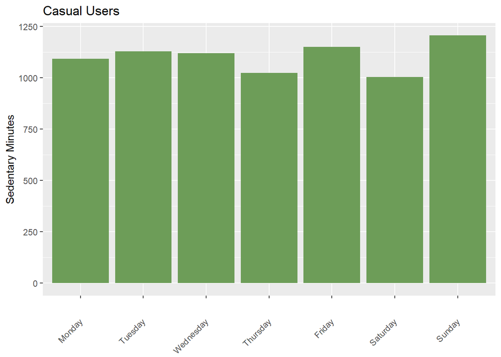

```r
ggplot(weekdays_casual_users, aes(x=day_of_week, y=daily_sedentary)) +
  geom_bar(stat = "identity", fill="#6D9D58") +
  labs(title = "Casual Users", x="", y="Sedentary Minutes") +
  theme(axis.text.x = element_text(angle=45, vjust=0.5, hjust=1))
```

## Repeat analysis for active users

**Identify which users are active**

```r
active_users <- user_type %>%
  filter(user_type =="active")
head(active_users)
```

```
## # A tibble: 3 × 6
##        Id mean_daily_cal mean_daily_sedentary mean_daily_steps mean_daily_weight
##     <dbl>          <dbl>                <dbl>            <dbl>             <dbl>
## 1  1.50e9          1997                  807            14915               116.
## 2  1.93e9          2151                  986              356               294.
## 3  2.87e9          1700.                 888.            8212.              126.
## # ℹ 1 more variable: user_type <chr>
```

## create a table filtered to active users to analyze their data

Note: creating a table filtered to active users

```r
active_users_daily <- daily_activity_weight %>%
  filter(Id %in% c("1503960366", "1927972279", "2873212765")) %>%
  group_by(Id)
head(active_users_daily)
```

```
## # A tibble: 5 × 21
## # Groups:   Id [3]
##           Id date       TotalSteps TotalDistance TrackerDistance
##        <dbl> <date>          <int>         <dbl>           <dbl>
## 1 1503960366 2016-05-02      14727          9.71            9.71
## 2 1503960366 2016-05-03      15103          9.66            9.66
## 3 1927972279 2016-04-13        356          0.25            0.25
## 4 2873212765 2016-04-21       8859          5.98            5.98
## 5 2873212765 2016-05-12       7566          5.11            5.11
## # ℹ 16 more variables: LoggedActivitiesDistance <dbl>,
## #   VeryActiveDistance <dbl>, ModeratelyActiveDistance <dbl>,
## #   LightActiveDistance <dbl>, SedentaryActiveDistance <dbl>,
## #   VeryActiveMinutes <int>, FairlyActiveMinutes <int>,
## #   LightlyActiveMinutes <int>, SedentaryMinutes <int>, Calories <int>,
## #   WeightKg <dbl>, WeightPounds <dbl>, Fat <int>, BMI <dbl>,
## #   IsManualReport <chr>, LogId <dbl>
```

### summarize the days of the week and how long(minutes) the active users were sedentary

Notes: creating a table to summarize the days of the week and how long(minutes) active users were sedentary.

```r
weekdays_active_users <- active_users_daily %>%
  mutate(day_of_week=weekdays(date))

weekdays_active_users$day_of_week <- ordered(weekdays_active_users$day_of_week,
                                             levels=c("Monday","Tuesday","Wednesday","Thursday","Friday","Saturday","Sunday"))

weekdays_active_users <- weekdays_active_users %>%
  group_by(day_of_week) %>%
  summarise(daily_sedentary=mean(SedentaryMinutes))
head(weekdays_active_users)
```

```
## # A tibble: 4 × 2
##   day_of_week daily_sedentary
##   <ord>                 <dbl>
## 1 Monday                 798
## 2 Tuesday                816
## 3 Wednesday              986
## 4 Thursday               888.
```

## Visualizing sedentary time of active users

Notes: creating a bar chart to visualize the days of the week and how long(minutes) active users were sedentary

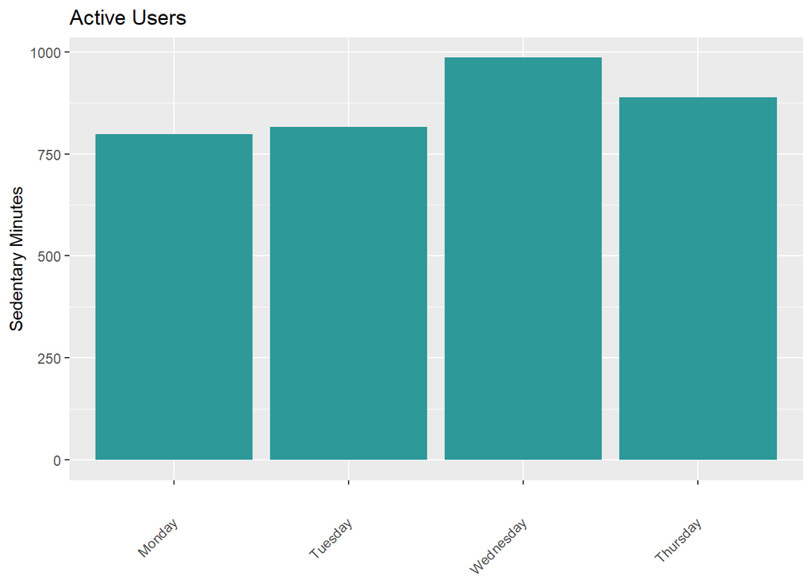

```r
ggplot(weekdays_active_users, aes(x=day_of_week, y=daily_sedentary)) +
  geom_bar(stat = "identity", fill="#2E9999") +
  labs(title = "Active Users", x="", y="Sedentary Minutes") +
  theme(axis.text.x = element_text(angle=45, vjust=0.5, hjust=1))
```

## ACT

### Recommendations Based on the activity trends of casual and active users.

Here are three key recommendations to help Bellabeat improve growth opportunities and refine its marketing strategy:

**2. Implement Daily and Week-day Programs**

Weekly Wellness Challenges: Launch challenges that starts on Monday, for instance, a step or hydration challenge that spans the week can motivate users to stay active across different days, catering to both segments.

Daily Check-Ins: Introduce a feature or reminder on a daily bases to engage in lighter activities, like meditation or a health quiz. This creates touch points that feel approachable for the users and enhances engagement without overwhelming them.

**3. Segmented Email and In-App Marketing**

Personalized Communication: Based on activity data, Bellabeat can send customized email or in-app notifications to users with detailed wellness insights and content that focuses on maintaining wellness habits .

Promote Device Features with User-Specific Relevance: For example, emphasize device features for tracking workouts to active users, while casual users could be nudged to use features like hydration tracking or sleep monitoring.

## Data Issues and Recommendations

This dataset provides valuable insights but has several limitations:

**1. Limited Data Collection Period**: Data was collected over just a few months, resulting in a smaller dataset. A longer study with a more diverse participant group is recommended to enhance the robustness of findings.

**2. Incomplete Weekly Data**: Some days lack data, likely due to the smart device not logging information or inconsistent device usage by participants. Ensuring that participants commit to daily device usage would improve data accuracy.

**3. Outdated Information**: The dataset is dated. Collecting data from 2020 onward would yield a more accurate representation of current trends and user behaviors. Addressing these issues can help future studies produce more comprehensive and reliable insights.

## Acknowledgement

This capstone project draws inspiration from a study by a Kaggle user, who analyzed the same dataset in their work titled Capstone Project: Case Study on Bellabeat. Their study served as a foundational reference, offering valuable insights into the analytical methods and code used in this project.